# Harmonized K=7 neighborhood-factor maps on ssDNA

Approved visualization-only analysis · rendered 2026-10-17T22:21:40

**Scope.** Frozen disease-blind K=7 Neighborhood-NMF results were mapped onto the chip-specific ssDNA images. No RCTD/NMF model was refitted and no disease hypothesis test was performed.

## Goal

Visualize the spatial distribution of the seven harmonized K=7 neighborhood-factor families across all 21 lung samples on their corresponding ssDNA backgrounds, and separately display continuous B-enriched/mixed-immune factor usage.

## Methods

Each frozen modelled Bin50 was linked to its stored patient and registered spatial coordinates. The previously validated inverse chip-specific affine transform was applied to map registered Bin50 centers into raw ssDNA pixel space. The categorical map assigns each Bin50 to the factor with the highest relative usage. The continuous map displays the chip-matched B-enriched/mixed-immune factor on a fixed 0–1 scale.

The seven frozen families were:

- Lymphatic-endothelial-associated
- Blood-endothelial-associated
- AT1-associated
- Perivascular-stromal-associated
- B-enriched/mixed-immune
- Ciliated-associated
- Fibroblast-associated

## Coverage and validation

**21** patients and **126,199** modelled Bin50 were mapped. All transformed Bin50 centers fell within their chip-specific ssDNA image bounds.

### Patients by disease

| disease | patient_n |
| --- | --- |
| HC | 6 |
| IPF | 6 |
| SSc-ILD | 9 |

### Coordinate validation

| chip | n_bins | inside_ssdna_fraction | ssdna_width | ssdna_height |
| --- | --- | --- | --- | --- |
| K8 | 27445 | 1.0 | 25926 | 24951 |
| J2 | 58772 | 1.0 | 26785 | 25837 |
| L3 | 39982 | 1.0 | 26792 | 25844 |

## Dominant K=7 factor on ssDNA

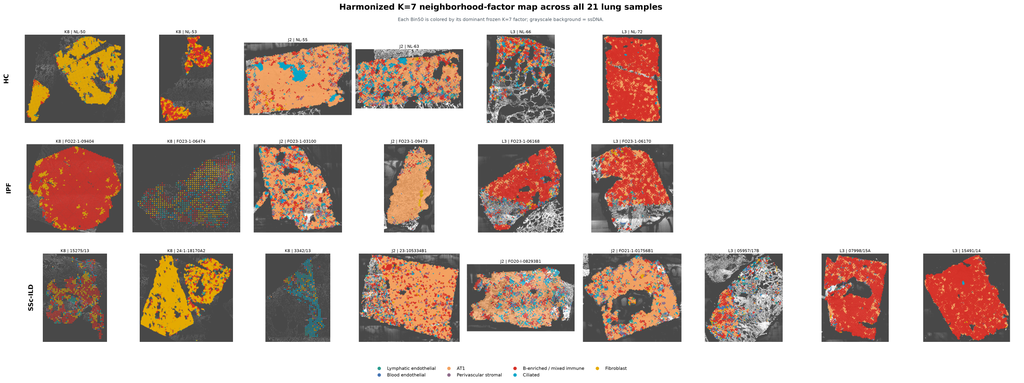

Figure 1. Each Bin50 is colored by its dominant frozen K=7 factor. Rows show HC, IPF, and SSc-ILD; panels are ordered by chip and patient. The grayscale background is ssDNA.

## B-enriched/mixed-immune continuous usage

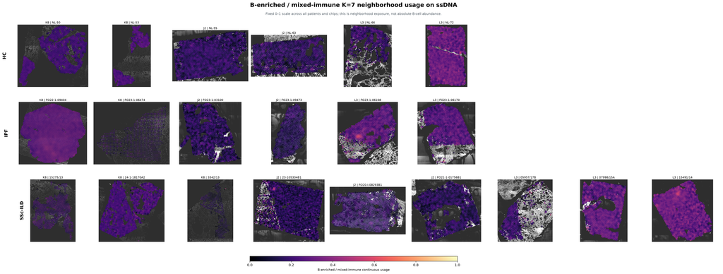

Figure 2. Continuous B-enriched/mixed-immune neighborhood usage on a fixed 0–1 scale. This quantity represents neighborhood exposure and must not be interpreted as absolute B-cell abundance.

## Interpretation boundaries

The maps are descriptive spatial visualizations of frozen factors. Differences in apparent color coverage are not formal disease comparisons. The B-enriched/mixed-immune factor is an immune-focused neighborhood factor supported by patient-paired expression analysis, but it is not a pure B-cell count. Cross-chip family labels come from the frozen harmonization and are not re-estimated here.

## Input provenance

| input | path | exists | sha256 |
| --- | --- | --- | --- |
| cross_chip_family_map | D:\Lung ST\codex agent\stereo_seq\stereo_seq\results\reanalysis\REFERENCE18_NEIGHBORHOOD_NMF_K7_STATE_SENSITIVITY_20261016_210302_attempt5\07_CROSS_CHIP_FAMILY_MAP.tsv | True | 26135d067918f0f699697ca2bc20216b6cceae26e3bd279f5d750d683ebb6d94 |
| coordinate_audit | D:\Lung ST\codex agent\stereo_seq\stereo_seq\results\ppt_qc\ssDNA_coordinate_audit.json | True | a4906e8f6abfe4790381b40d19fdc1f7a8ba2e181a762bdf98fbd3e6a908d445 |
| model_K8 | D:\Lung ST\codex agent\stereo_seq\stereo_seq\results\reanalysis\REFERENCE18_NEIGHBORHOOD_NMF_K7_K12_EXTENSION_20261015_attempt5\models\neighborhood50_K8_K07_MODEL_AND_USAGE.npz | True | bd0dc67ff5b6fd16b2e7a45f76ba32464120a63961dfcc2e29c6e709a6815159 |
| metadata_K8 | D:\Lung ST\codex agent\stereo_seq\stereo_seq\results\reanalysis\REFERENCE18_UMI50_VOLTRON_PER_CHIP_NICHE_20261005_153036\K8\01_FROZEN_REFERENCE18_INPUT.tsv.gz | True | 7266c845603fdb0ee028df4a2269da247ff9904e49bb1a2bc28de8c262948601 |
| ssdna_K8 | D:\Lung ST\chip\chip 1\QC\Y40102K8_20260428_204657\Y40102K8_SC_20260428_204657_4.2.2\ssDNA\Experiment-64-ApoTome-01-Stitching-02_ORG.tif | True | not_computed_large_tiff |
| model_J2 | D:\Lung ST\codex agent\stereo_seq\stereo_seq\results\reanalysis\REFERENCE18_NEIGHBORHOOD_NMF_K7_K12_EXTENSION_20261015_attempt5\models\neighborhood50_J2_K07_MODEL_AND_USAGE.npz | True | d446faa293246b1ca92398763eb3b0e0456d456d90e055442332ae72a4903d92 |
| metadata_J2 | D:\Lung ST\codex agent\stereo_seq\stereo_seq\results\reanalysis\REFERENCE18_UMI50_VOLTRON_PER_CHIP_NICHE_20261005_153036\J2\01_FROZEN_REFERENCE18_INPUT.tsv.gz | True | fea58920cb28fa6aeaff19782806135887743245ea03c72291d99bd43a4975b9 |
| ssdna_J2 | D:\Lung ST\chip\chip 2\QC\Y40105J2_20260520_160413\Y40105J2_SC_20260520_160413_4.2.2\ssDNA\Y40105J2.tif | True | not_computed_large_tiff |
| model_L3 | D:\Lung ST\codex agent\stereo_seq\stereo_seq\results\reanalysis\REFERENCE18_NEIGHBORHOOD_NMF_K7_K12_EXTENSION_20261015_attempt5\models\neighborhood50_L3_K07_MODEL_AND_USAGE.npz | True | 6b1802546c509a2e98526c7219f40259898c618e68fa023ad26007d848f505dc |
| metadata_L3 | D:\Lung ST\codex agent\stereo_seq\stereo_seq\results\reanalysis\REFERENCE18_UMI50_VOLTRON_PER_CHIP_NICHE_20261005_153036\L3\01_FROZEN_REFERENCE18_INPUT.tsv.gz | True | 0613946cab1f86631ea8057cb9e991f6f1992a25387e02405402966b3d294d20 |
| ssdna_L3 | D:\Lung ST\chip\chip 3\QC\Y40105L3_20260522_205054\Y40105L3_SC_20260522_205054_4.2.2\ssDNA\YY40105L3.tif | True | not_computed_large_tiff |

## Execution log

```
Workflow: frozen harmonized K=7 maps on ssDNA
Date: 2026-10-17T22:11:56
Command: envs/stereo_seq_py/Scripts/python.exe scripts/1157_render_reference18_k7_ssdna_maps.py
Output: D:\Lung ST\codex agent\stereo_seq\stereo_seq\results\reanalysis\REFERENCE18_K7_SSDNA_MAPS_261017220004
NMF/RCTD refit: no
Disease test: no
Status: PASS
```

## Session information

```
Python: 3.12.14 (main, Aug 25 2026, 14:01:42) [MSC v.1944 64 bit (AMD64)]
Platform: Windows-11-10.0.26200-SP0
numpy: 2.4.6
pandas: 3.0.5
matplotlib: 3.11.1
```

**Report SHA-256:** written to the adjacent `.sha256.txt` file after rendering.